# Marketing Campaign Data Example

Aleksandr Tsybakin[^1]

Vadim Tyuryaev[^2]

Jane Heffernan[^3]

Hanna Jankowski[^4]

Kevin McGregor[^5]

## Initial Setup

Import packages.

```r
suppressMessages(library(ggplot2))
suppressMessages(library(visdat))
suppressMessages(library(forcats))
suppressMessages(library(corrplot))
suppressMessages(library(ggpubr))
suppressWarnings(library(gridExtra))
suppressMessages(library(tibble))
suppressMessages(library(dplyr))
suppressMessages(library(naniar))
suppressMessages(library(devtools))
suppressMessages(library(glmnet))
suppressMessages(library(selectiveInference))
```

Install and import [RegrCoeffsExplorer](https://github.com/vadimtyuryaev/RegrCoeffsExplorer/tree/main) package (Tyuryaev et al. 2024).

```r
devtools::install_github("vadimtyuryaev/RegrCoeffsExplorer",
                         ref="main",
                         build_vignettes=TRUE)
```

```
## Skipping install of 'RegrCoeffsExplorer' from a github remote, the SHA1 (ed53fec0) has not changed since last install.
##   Use `force = TRUE` to force installation
```

```r
suppressMessages(library(RegrCoeffsExplorer))
```

We implemented several helper functions that will be re-used throughout examples under this tutorial.

```r
source("./utils/utils.R")
```

## Introduction

In this section we will explore the Customer Personality Analysis dataset. This dataset was created by the *IFood* Company which is a delivery app in Brazil. This dataset was composed to analyze behavior of Company’s customers to maximize profit of marketing campaigns. The dataset contains information about 2240 customers that was pulled from Company’s Customer Relationship Management (CRM) systems. It’s attributes are grouped in the following manner:

1. *People* - customer general information such as Birth Year, Education, Income, etc.
2. *Products* - data about customers’ purchases such as amount spent on Fruits, Meat, etc.
3. *Promotions* - data that indicates if a customer accepted any of the previous offers under previous campaigns.
4. *Places* - information about source of customers’ purchases e.g. website, store and catalog.

The goal for this research exercise is to analyze the factors that drive Company’s customers to accept the offer under the latest campaign. We will perform Exploratory Data Analysis (Tukey et al. 1977) first and then fit a GLMNET model to understand the factors that affect customers’ decisions.

More details can be found in [Dataset Data Card on Kaggle platform](https://www.kaggle.com/datasets/imakash3011/customer-personality-analysis) and [github page](https://github.com/nailson/ifood-data-business-analyst-test/) where the dataset was published.

```r
# Read data
df_mp = read.csv("./data/marketing_campaign/marketing_campaign.csv", sep="\t")
df_mp = as_tibble(df_mp)
df_mp = df_mp%>%mutate_if(is.character, as.factor)
dim(df_mp)
```

```
## [1] 2240   29
```

## Exploratory Data Analysis

### Missing Values

Let’s take a closer look at the data. We will start with exploring missing values in the dataset.

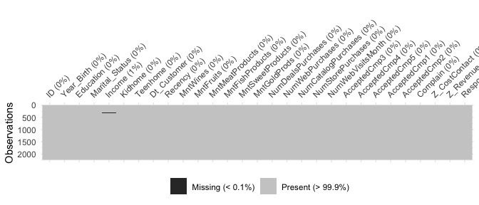

```r
# Plot missing values matrix
vis_miss(df_mp)
```

```r
# remove NA values
df_mp = na.omit(df_mp)
```

Now we can take a look at the distributions of categorical and numerical variables. However, we will remove `ID`, `Z_CostContact` and `Z_Revenue` variables from the dataset. This is because we do not need the first one in our further analysis (unique identifier), and there is no description on the Kaggle platform for the other two variables.

```r
# Remove 'ID', 'Z_CostContact' and 'Z_Revenue' columns from dataset
# No descriptions for Z-columns
df_mp = subset(df_mp, select=-c(ID, Z_CostContact, Z_Revenue))
```

### Categorical Variables

Let’s look at distributions of categorical variables.

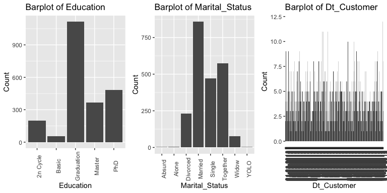

```r
# Select categorical variables
factor_vars = df_mp %>%
  select_if(is.factor)

# Plot barplots for factor variables
plot_figures(factor_vars, ncol=3, plot_type="bar")
```

First let’s analyze categorical variables. From the plots above we can see several things:

1. Working with dates such as `Dt_Customer` variable is challenging. For this reason, we will calculate the number of years the customer is enrolled in Company’s system.
2. `Kidhome`, `Teenhome` and `Response` should be categorical variables as they consists of integer values only and represent groupings of customers under certain conditions (e.g. number of kids), we will transform them to factors variables.
3. Also, `Kidhome`, `Teenhome`, `Marital_Status` and `Education` variables are imbalanced, we will re-balance the variables into two groups - majority group vs others groups combined together.

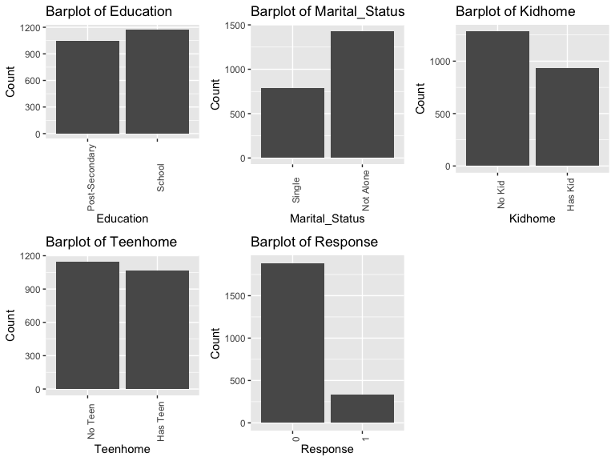

```r
# Take a year from the enrollment date
df_mp$Dt_Customer = as.numeric(format(as.Date(df_mp$Dt_Customer, format="%d-%m-%Y"),"%Y"))

# Convert numeric variables into factors variables
df_mp$Kidhome = as.factor(df_mp$Kidhome)
df_mp$Teenhome = as.factor(df_mp$Teenhome)
df_mp$Response = as.factor(df_mp$Response)


# Collapse factors
df_mp[["Kidhome"]] = fct_collapse(df_mp[["Kidhome"]], "Has Kid"=c(1, 2),
                                  "No Kid"=c(0))
df_mp[["Teenhome"]] = fct_collapse(df_mp[["Teenhome"]], "Has Teen"=c(1, 2),
                                   "No Teen"=c(0))
df_mp[["Marital_Status"]] = fct_collapse(df_mp[["Marital_Status"]],
                                         "Single"=c("Absurd", "Alone", "Divorced",
                                                    "Single", "Widow", "YOLO"),
                                         "Not Alone"=c("Married", "Together"))
df_mp[["Education"]] = fct_collapse(df_mp[["Education"]],
                                         "School"=c("Basic", "Graduation"),
                                         "Post-Secondary"=c("2n Cycle", "Master",
                                                            "PhD"))

# Select categorical variables
factor_vars = df_mp %>%
  select_if(is.factor)

# Plot barplots for factor variables
plot_figures(factor_vars, ncol=3, plot_type="bar")
```

Now the categorical variables are more even. Let’s analyze continuous variables and prepare them for modelling.

### Continuous Variables

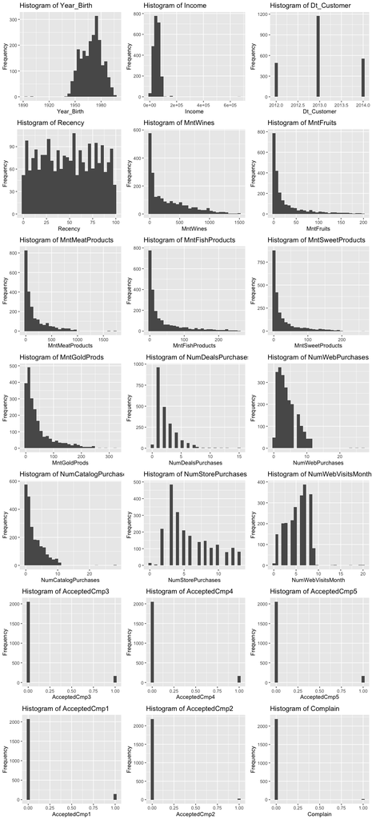

```r
# Select continuous variables
continuous_vars = df_mp %>%
  select_if(is.numeric)

# Plot histograms for numerical variables
plot_figures(continuous_vars, ncol=3, plot_type="hist")
```

From the histograms above, we can make two initial observations:

1. `Complain` variable is highly imbalanced and skewed towards *No complain*. We will remove it from our further analysis.
2. All *Promotion* variables are also highly unbalanced towards 0 which indicates that most of Company’s customers do not tend to accept previous offers. We will combine them into one binary variable `AcceptedCmp` that will indicate if a customer accepted at least one of these offers.

```r
# Remove 'Complain' as it is highly imbalanced
df_mp = subset(df_mp, select=-c(Complain))

# Convert variables about previous campaigns into one variable that
# indicates if a client has ever participated in at least one campaign
df_mp$AcceptedCmp = df_mp$AcceptedCmp1 + df_mp$AcceptedCmp2 + df_mp$AcceptedCmp3 + df_mp$AcceptedCmp4 + df_mp$AcceptedCmp5
df_mp$AcceptedCmp = as.factor(df_mp$AcceptedCmp)
df_mp[["AcceptedCmp"]] = fct_collapse(df_mp[["AcceptedCmp"]],
                                      "Accepted an Offer"=c(1, 2, 3, 4),
                                      "No offers accepted"=c(0))

# Remove previous campaigns variables
df_mp = subset(df_mp, select=-c(AcceptedCmp1,
                                AcceptedCmp2,
                                AcceptedCmp3,
                                AcceptedCmp4,
                                AcceptedCmp5))
```

In addition to this, from the histogram plots above we can see that all *Products* variables are skewed and have heavy right tails. We will combine them into one variable `Total_Expenses` that indicates total expenses on all types of products.

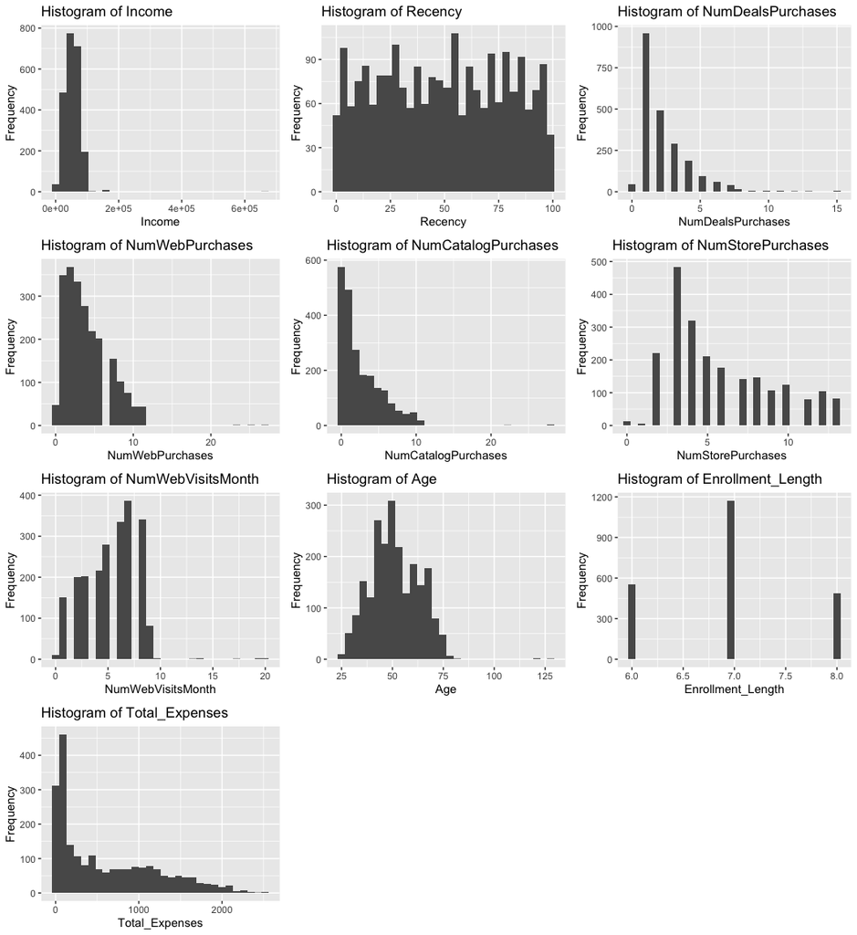

```r
# Set a current year (approximate year when the data was released,
# ref: https://github.com/nailson/ifood-data-business-analyst-test/
CUR_YEAR = 2020

# Calculate customers' age
df_mp$Age = CUR_YEAR - df_mp$Year_Birth

# Calculate number of years since customers' enrollment
df_mp$Enrollment_Length = CUR_YEAR - df_mp$Dt_Customer

# Count all expenses of of several sectional expenses variables
df_mp$Total_Expenses = df_mp$MntWines + df_mp$MntFruits + df_mp$MntMeatProducts + df_mp$MntFishProducts + df_mp$MntSweetProducts + df_mp$MntGoldProds

# Remove not needed columns
df_mp = subset(df_mp, select=-c(Year_Birth, Dt_Customer, MntWines, MntFruits,
                                MntMeatProducts, MntFishProducts,
                                MntSweetProducts, MntGoldProds))

# Select continuous variables
continuous_vars = df_mp %>%
  select_if(is.numeric)

# Plot histograms for numerical variables
plot_figures(continuous_vars, ncol=3, plot_type="hist")
```

We can see that `Enrollment_Length` have only three integer values which split customers into three groups. For this reason, we will convert this variable to factor type.

```r
# Convert to factor as it has only 3 possible integer values
df_mp$Enrollment_Length = as.factor(df_mp$Enrollment_Length)
```

Also, some numerical variables have outliers in their distributions (e.g. `Income`, `NumWebPurchases`, etc.). We will remove them using *1.5 Interquartile Range (IQR) rule* to avoid any impact from outliers on performance of our model. The IQR rule is implemented in the *get_bounds_iqr()* function. The *count_outliers_iqr()* function counts number of outliers per variable.

```r
# Get Upper and Lower limit according to the 1.5 IQR rule
get_bounds_iqr = function(data, num_var) {
  Q1 = quantile(data[[num_var]], probs=.25, na.rm=FALSE)[["25%"]]
  Q3 = quantile(data[[num_var]], probs=.75, na.rm=FALSE)[["75%"]]
  IQR = Q3 - Q1

  Lower = Q1 - 1.5 * IQR
  Upper = Q3 + 1.5 * IQR

  return(c(Lower, Upper))
}

# Get number of outliers according to the 1.5 IQR rule
count_outliers_iqr = function(data, num_var) {
  bounds = get_bounds_iqr(data, num_var)
  return(nrow(data[data[[num_var]] < bounds[1] | data[[num_var]] > bounds[2], ]))
}
```

Let’s see how many outliers per variable we have in the dataset.

```r
# Select continuous variables
continuous_vars = df_mp %>%
  select_if(is.numeric)

# Count number of total outliers
total_num_outliers = 0

# Iterate through numerical columns and get number of outliers according to the 1.5 IQR rule
# for each column
for (col in colnames(continuous_vars)) {
  print(col)
  cur_num_outliers = count_outliers_iqr(df_mp, col)
  print(cur_num_outliers)
  total_num_outliers = total_num_outliers + cur_num_outliers
}
```

```
## [1] "Income"
## [1] 8
## [1] "Recency"
## [1] 0
## [1] "NumDealsPurchases"
## [1] 84
## [1] "NumWebPurchases"
## [1] 3
## [1] "NumCatalogPurchases"
## [1] 23
## [1] "NumStorePurchases"
## [1] 0
## [1] "NumWebVisitsMonth"
## [1] 8
## [1] "Age"
## [1] 3
## [1] "Total_Expenses"
## [1] 3
```

```r
# Display total number of outliers
total_num_outliers
```

```
## [1] 132
```

We can see that `NumDealsPurchases` has the most number of outliers. In total we have 132 outliers in all numerical variables. Please note: these are not unique counts, and outliers records might overlap for several variables.

Now let’s remove outliers from the dataset.

```r
# Get number of rows before removal of outliers
nrow(df_mp)
```

```
## [1] 2216
```

```r
# Remove outliers identified above
var_bounds = list()

# Store all bound before removal as sequential removal changes variables distributions:
# distributions for other variables got affected while removing rows from dataframe
# with one outlier variable
for (col in colnames(continuous_vars)) {
  var_bounds[[col]] = get_bounds_iqr(df_mp, col)
}

for (col in names(var_bounds)) {
  df_mp = df_mp[df_mp[[col]] >= var_bounds[[col]][1] & df_mp[[col]] <= var_bounds[[col]][2], ]
}
# Get number of rows after removal, it does not match with the total number of outliers
# as that number counts non-unique rows in the dataset (e.g. one row contains two outliers)
nrow(df_mp)
```

```
## [1] 2095
```

In total we removed 121 records (2216 rows before deleting and 2095 rows after). Let’s check correlations in the dataset among continuous variables.

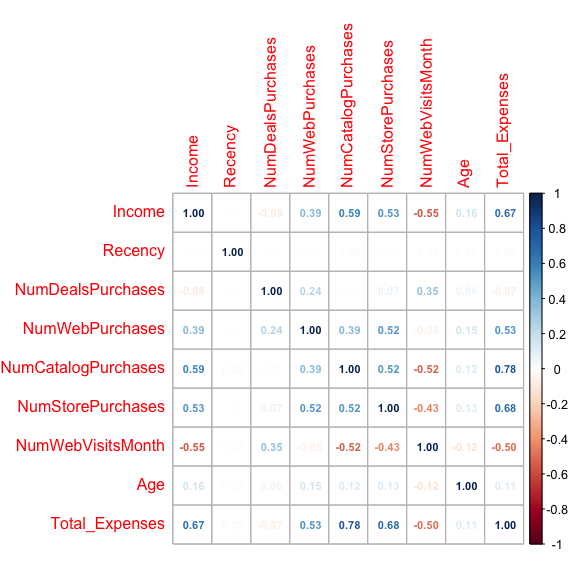

```r
# Get the correlation matrix
cor_matrix = cor(continuous_vars)

# Plot the correlation matrix
corrplot(cor_matrix, method = "number", number.cex=0.7)
```

We will remove `Total_Expenses` variable as it has correlations with several other numerical variables in the dataset.

```r
# Remove 'Total_Expenses' as it correlates with multiple other variables
df_mp = subset(df_mp, select=-c(Total_Expenses))
```

## Modelling

Now we are ready to fit a model on the data to explore factors that influence Customers’ in their decision on accepting marketing campaign offers. We will build a *GLMNET* model to fit a LASSO regression ($\alpha = 1$) with *binomial* family.

We will build a *model.matrix* object based on the dataset, select the best $\lambda$ parameter based on Cross-Validation and build a *GLMNET* model with the selected $\lambda$ parameter. We will select $\lambda$ that gives a minimum Binomial Deviance based on Cross Validation.

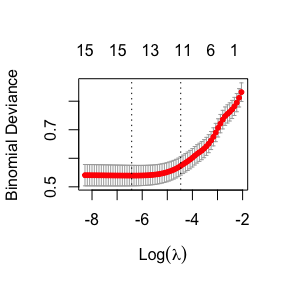

```r
# Get Lasso model
y_lasso = df_mp$Response
x_lasso = model.matrix(as.formula(paste("~",
        paste(colnames(subset(df_mp, select=-c(Response))),
              collapse="+"),
        sep="")),
        data=df_mp)
x_lasso = x_lasso[, -1]

ndim_lasso = dim(x_lasso)[1]

# Select the best lambda
cv_model_lasso = cv.glmnet(x_lasso, y_lasso, family="binomial", alpha=1)
best_lambda_lasso = cv_model_lasso$lambda.min
plot(cv_model_lasso)
```

```r
# Get a model with the best lambda
best_model_lasso = glmnet(x_lasso, y_lasso, family="binomial", alpha=1,
                          lambda=best_lambda_lasso)
summary(best_model_lasso)
```

```
##            Length Class     Mode
## a0          1     -none-    numeric
## beta       15     dgCMatrix S4
## df          1     -none-    numeric
## dim         2     -none-    numeric
## lambda      1     -none-    numeric
## dev.ratio   1     -none-    numeric
## nulldev     1     -none-    numeric
## npasses     1     -none-    numeric
## jerr        1     -none-    numeric
## offset      1     -none-    logical
## classnames  2     -none-    character
## call        6     -none-    call
## nobs        1     -none-    numeric
```

```r
coef(best_model_lasso)
```

```
## 16 x 1 sparse Matrix of class "dgCMatrix"
##                                         s0
## (Intercept)                  -3.5987082250
## EducationSchool              -0.3646593337
## Marital_StatusNot Alone      -1.1217733247
## Income                        0.0000382334
## KidhomeHas Kid                .
## TeenhomeHas Teen             -1.6214135892
## Recency                      -0.0279205040
## NumDealsPurchases             0.2398198937
## NumWebPurchases               0.0160824615
## NumCatalogPurchases           0.1819782708
## NumStorePurchases            -0.2263166730
## NumWebVisitsMonth             0.2386793370
## AcceptedCmpAccepted an Offer  1.9415494935
## Age                           .
## Enrollment_Length7            0.4542722653
## Enrollment_Length8            1.4971754468
```

Let’s use the *vis_reg()* function to see what the effect on the target variable would be from an increment of the difference between the median and minimum for each variable.

More details on *vis_reg()* function can be found in our [vignette](https://vadimtyuryaev.github.io/RegrCoeffsExplorer/articles/BetaVisualizer.html):

```r
# load OddsRatioVisualizer vignette
vignette("BetaVisualizer",
         package="RegrCoeffsExplorer")
```

```
## starting httpd help server ... done
```

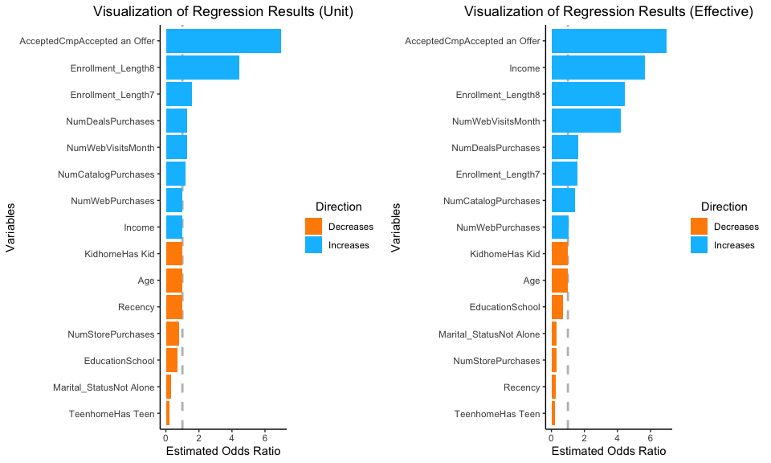

```r
# Plot Odds Ratio for one Unit Difference vs. Odds Ratio for median and minimum difference
# Note: we define categorical variables in 'glmnet_fct_var' parameter
grid.arrange(vis_reg(best_model_lasso, palette=c("deepskyblue","darkorange"),
                    eff_size_diff=c(1, 3),
                    glmnet_fct_var=c("AcceptedCmpAccepted an Offer",
                                    "EducationSchool", #"KidhomeHas Kid",
                                    "Marital_StatusNot Alone", "TeenhomeHas Teen",
                                    "Enrollment_Length7", "Enrollment_Length8"))$"SidebySide")
```

Now let’s take at the Odds Ratio plots for numerical variables. We will customize plots similarly to the previous example with the Heart Attack Data (please see the [vignette](https://vadimtyuryaev.github.io/RegrCoeffsExplorer/articles/OddsRatioVisualizer.html)) for more details:

```r
# load OddsRatioVisualizer vignette
vignette("OddsRatioVisualizer",
         package="RegrCoeffsExplorer")
```

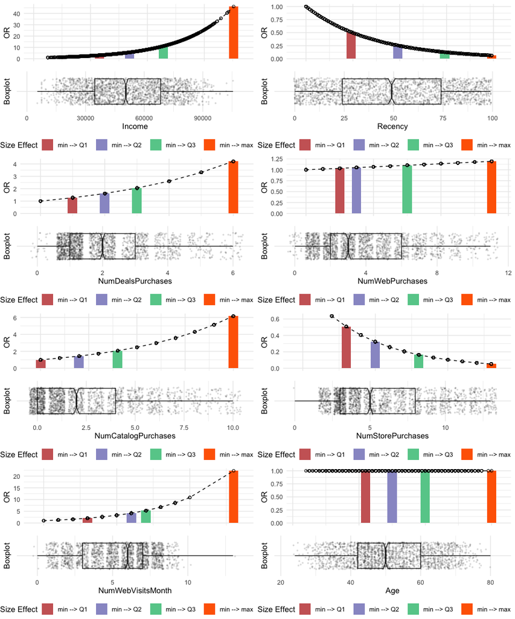

```r
# Select continuous variables
continuous_vars = df_mp %>%
  select_if(is.numeric)

# Create a list to store all plots
plot_list = list()

# Store side by side graphs for all numeric variables
for (name in colnames(continuous_vars)) {
  # Customize graph through layers and color parameter
  or_plots = plot_OR(best_model_lasso, df_mp, var_name=name,
                     color_filling=c("#CC6666", "#9999CC","#66CC99","#FF6600"))

  # Plot both graphs together
  plot_list[[name]] = customized_plots(or_plots)
}

# Plot all graphs in one matrix
plot_grob = arrangeGrob(grobs=plot_list, ncol=2)
grid.arrange(plot_grob)
```

Similarly to the Heart Attack example, we can make two counter-intuitive observations:

1. *Chance of acceptance of next campaign decreases as number of store purchases increases*. However, we can see the opposite tendency in number of web visits and number of web purchases. One possible explanation could be if the campaign is offered online and customers that shop offline are not aware of it. The Company might need to advertise their offers in-store more.
2. *Age does not affect the chance of acceptance of next campaign*. From the coefficient values above we can see that Lasso regression zeros this `Age` variable out. One direction that the Company might consider is making targeting certain age groups under their marketing campaigns to make more use of this characteristic.

## References

Tukey, John Wilder et al. 1977. *Exploratory Data Analysis*. Vol. 2. Springer.

Tyuryaev, Vadim, Aleksandr Tsybakin, Jane Heffernan, Hanna Jankowski, and Kevin McGregor. 2024. *RegrCoeffsExplorer: Efficient Visualization of Regression Coefficients for LM, GLM, and GLMNET Objects*. https://vadimtyuryaev.github.io/RegrCoeffsExplorer/.

[^1]: York University, Mathematics and Statistics, tsybakin@yorku.ca
[^2]: York University, Mathematics and Statistics, vadimtyu@yorku.ca
[^3]: York University, Mathematics and Statistics, jmheffer@yorku.ca
[^4]: York University, Mathematics and Statistics, hkj@yorku.ca
[^5]: York University, Mathematics and Statistics, kevinmcg@yorku.ca